# Exploratory Data Analysis

JVWCD Capstone Group

2/20/2022

# 1 Business Statement

There is a strong correlation between water usage and weather patterns in the water industry. Water usage increases during warmer and drier periods, and when it’s colder and wetter, water usage is typically less. Jordan Valley Water Conservancy District (JVWCD) has noticed this trend and is wanting to find a solution that will allow them to be more proactive and not so reactive to changes in water demand with these seasonal trends.

Historically, operations staff have worked in a reactive state chasing water demands of community members, which is influenced by changing weather. Most of this variability happens in the summer, with residential outdoor landscape watering being the leading consumer. Roughly 65% of the community’s water use is in that outdoor landscape space. This reactive chase ensures that the community always has water, which often requires water managers, supervisors and operators to spend long hours (including overtime hours), watching and reacting to changes in water demand. Managing the system’s water demand can be like steering a large ship – sudden and abrupt changes are not easily absorbed. Also, there is a cost factor to this. Well-informed planning to operate the system with consistency and minor tweaks saves money. However, operational costs can add up quickly if a well is started at an unplanned time. This event could cost the water system $5,000 to $9,000 in electricity demand charges alone.

JVWCD would like to be more efficient with its resources and manpower. The goal of this capstone project is to explore modeling water demand against weather data. The ideal outcome of this project would be a predictive model that gives the operations team more confidence in making decisions related to water demand so that they can move to a more proactive form of water deliveries.

# 2 Analytic Objectives

System demand is calculated by adding all the individual sources and subtracting the reservoir trends from the total. JVWCD has provided system data to use for modeling. This is time series data and will require some cleaning before use in a model.

Our analytic objective in this project will be to develop a model that utilizes past weather and water demand data to provide water demand predictions for the JVWCD Operations Staff.

# 3 Exploratory Questions

The questions below were crafted prior to our EDA. We used these questions to help guide our EDA and added to it during our EDA.

Is there strong correlations between the different weather metrics and the different point type? Do we see a seasonal trend with the data? Can the weather forecast help predict demand? How does weather change season by season? Is there anything useful with hourly data vs. daily weather data? How does demand change from month to month? Is there a correlation between demand and temperature, and how strong is that correlation? What are the best predictor variables to help predict daily demand? How does the seasonal variation change the hourly water demand?

# 4 Read Data

## 4.1 Packages

```r
list.of.packages <- c("tidyverse",
                      "lubridate",
                      "chron",
                      "knitr",
                      "corrplot",
                      "caret",
                      "scales",
                      "gridExtra",
                      "useful",
                      "ISOweek",
                      "kableExtra")
new.packages <- list.of.packages[!(list.of.packages %in% installed.packages()[,"Package"])]
if(length(new.packages)) install.packages(new.packages)

library(tidyverse)
library(lubridate)
library(chron)
library(knitr)
library(corrplot)
library(caret)
library(scales)
library(gridExtra)
library(useful)
library(ISOweek)
library(kableExtra)
```

## 4.2 Read CSV files and pre process

```r
#read in data. Change names to be more readable and make hourly demand numeric
sd <- read.csv("2_year_system_demand.csv")%>%
  rename('hourly_demand' = 'Hourly.Demand..cfs.',
         'date_time' = 'Read.Date.Time')%>%
  mutate(hourly_demand = as.numeric(hourly_demand),
         hourly_demand = ifelse(is.na(hourly_demand),0,hourly_demand)) #What do we do with NA's???

#Make Date and Time match a consistent format with the Weather Data
sd2 <- as.data.frame(str_split_fixed(sd$date_time, " ", 3))%>%
  rename(date = V1, time = V2, am_or_pm = V3)%>%
  mutate(datetime_str = paste(date, time, am_or_pm),
         datetime = as.POSIXct(strptime(datetime_str, format = "%m/%d/%y %I:%M %p")),
         datetime_military = strftime(datetime, format = "%m/%d/%Y %H:%M")) %>%
  select(datetime,datetime_military)
sd3 <-as.data.frame(str_split_fixed(sd2$datetime_military, " ", 2))%>%
  rename(date = V1, time = V2)
sd4 <-as.data.frame(str_split_fixed(sd3$date, "/", 3))%>%
  rename(CalendarMonth = V1,  CalendarDay = V2, CalendarYear = V3)
#Throw it all together
sd <- cbind(sd,sd2,sd3,sd4)%>%
  select(-date_time)
#Get rid of temp dfs
remove(sd2,sd3,sd4)

#The names and dates in this table do not need much conversion
wa <- read.csv("weather_sl_airport.csv")



sp <- read.csv("system_demand_by_point_type.csv")%>%
  rename('date_time' = 'Read.Date.Time',
         'well_flow_cfs' = 'Well.Flow..cfs.',
         'purchased_flow_cfs' = 'Purchased.Flow..cfs.',
         'transported_flow_cfs' = 'Transported.Flow..cfs.',
         'treated_flow_cfs' = 'Treated.Flow..cfs.',
         'injected_flow_cfs' = 'Injected.Flow..cfs.',
         'reservoir_trend_cfs' = 'Reservoir.Trend..cfs.',)
#Make Date and Time match a consistant format with the Weather Data
sp2 <- as.data.frame(str_split_fixed(sp$date_time, " ", 3))%>%
  rename(date = V1, time = V2, am_or_pm = V3)%>%
  mutate(datetime_str = paste(date, time, am_or_pm),
         datetime = as.POSIXct(strptime(datetime_str, format = "%m/%d/%y %I:%M %p")),
         datetime_military = strftime(datetime, format = "%m/%d/%Y %H:%M")) %>%
  select(datetime,datetime_military)
sp3 <-as.data.frame(str_split_fixed(sp2$datetime_military, " ", 2))%>%
  rename(date = V1, time = V2)
sp4 <-as.data.frame(str_split_fixed(sp3$date, "/", 3))%>%
  rename(CalendarMonth = V1,  CalendarDay = V2, CalendarYear = V3)
#Throw it all together
sp <- cbind(sp,sp2,sp3,sp4)%>%
  mutate(reservoir_trend_cfs = as.numeric(reservoir_trend_cfs))%>%
  select(-date_time)
#Get rid of temp dfs
remove(sp2,sp3,sp4)
```

> Something important to note is that the weather data is daily and demand data is hourly so we should ask if they want to change to hourly weather data or as how we want to aggregate daily demand so we can match the grain for our model.

## 4.3 Outlier analysis

```r
#Also note below some errors found and questions raised on initial data inspection.
sd %>%
  filter(hourly_demand<0)%>%
  kable()
```

| hourly_demand | datetime | datetime_military | date | time | CalendarMonth | CalendarDay | CalendarYear |
| --- | --- | --- | --- | --- | --- | --- | --- |
| -49.67661 | 2021-01-01 12:59:00 | 01/01/2021 12:59 | 01/01/2021 | 12:59 | 01 | 01 | 2021 |
| -142.61861 | 2021-03-01 06:59:00 | 03/01/2021 06:59 | 03/01/2021 | 06:59 | 03 | 01 | 2021 |
| -14.15972 | 2021-03-05 09:59:00 | 03/05/2021 09:59 | 03/05/2021 | 09:59 | 03 | 05 | 2021 |

> It appears that there are 3 instances with negative hourly demand.Does this actually mean that water was given back or is this an error?

```r
sd %>%
  group_by(CalendarDay) %>%
  summarize(count=n())%>%
  kable()
```

| CalendarDay | count |
| --- | --- |
|  | 2 |
| 01 | 576 |
| 02 | 576 |
| 03 | 576 |
| 04 | 576 |
| 05 | 576 |
| 06 | 576 |
| 07 | 576 |
| 08 | 574 |
| 09 | 576 |
| 10 | 576 |
| 11 | 576 |
| 12 | 576 |
| 13 | 576 |
| 14 | 574 |
| 15 | 576 |
| 16 | 576 |
| 17 | 576 |
| 18 | 576 |
| 19 | 576 |
| 20 | 576 |
| 21 | 576 |
| 22 | 576 |
| 23 | 576 |
| 24 | 576 |
| 25 | 576 |
| 26 | 576 |
| 27 | 576 |
| 28 | 576 |
| 29 | 552 |
| 30 | 528 |
| 31 | 336 |

> There is not an entry for each hour of each day of each year. We are missing 2 hours on the 8th and 14th of some year

```r
sd[sd$time %in% "",]%>%
  kable()
```

|  | hourly_demand | datetime | datetime_military | date | time | CalendarMonth | CalendarDay | CalendarYear |
| --- | --- | --- | --- | --- | --- | --- | --- | --- |
| 1610 | 88.50042 | NA | NA |  |  |  |  |  |
| 10513 | 0.00000 | NA | NA |  |  |  |  |  |

> It looks like row 1610 show that we don’t have data for 01h00 - 04h00 on 3/8/2020. One row is NA, and there is a missing column. And the exact same gap on row 10513 03/14/2021. Is there possibly some planned maintenance going on in early March of each year?

## 4.4 Add a Season Variable to All Tables

```r
sd <- sd%>%
  mutate(season = ifelse(CalendarMonth %in% c('03','04','05'), 'Spring',
                         ifelse(CalendarMonth %in% c('06','07','08'), 'Summer',
                                ifelse(CalendarMonth %in% c('09','10','11'), 'Fall',
                                       ifelse(CalendarMonth %in% c('12','01','02'), 'Winter','0')))))%>%
  filter(season != '0')


sp <- sp%>%
  mutate(season = ifelse(CalendarMonth %in% c('03','04','05'), 'Spring',
                         ifelse(CalendarMonth %in% c('06','07','08'), 'Summer',
                                ifelse(CalendarMonth %in% c('09','10','11'), 'Fall',
                                       ifelse(CalendarMonth %in% c('12','01','02'), 'Winter','0')))))%>%
  filter(season != '0')


wa <- wa%>%
  mutate(season = ifelse(CalendarMonth %in% c('3','4','5'), 'Spring',
                         ifelse(CalendarMonth %in% c('6','7','8'), 'Summer',
                                ifelse(CalendarMonth %in% c('9','10','11'), 'Fall',
                                       ifelse(CalendarMonth %in% c('12','1','2'), 'Winter','0')))))%>%
  filter(season != '0')
#This does filter out any values without a date.
```

## 4.5 System Demand Joined to Weather Data from Salt Lake Airport

```r
#Snapshot View
sd1 <- sd%>%
  group_by(date)%>%
  summarise(daily_demand = mean(hourly_demand),
            CalendarMonth = CalendarMonth,
            CalendarDay = CalendarDay,
            CalendarYear = CalendarYear,
            season = season)
wa1 <- wa%>%
  select(-CalendarYear,-CalendarMonth,-CalendarDay,-season)%>%
  rename(date = WeatherDate)

wd <- merge(wa1,sd1,by="date")

# Factor RainDays
wd <- wd%>%
  mutate(RainDays = factor(RainDays))

#Get rid of temp dfs
remove(sd1,sd2,wa1)
kable(head(wd))
```

| date | TemperatureMax | TemperatureMin | TemperatureMean | Precipitation | CoolingDegreeDays | SnowDepth | SnowFall | RainDays | daily_demand | CalendarMonth | CalendarDay | CalendarYear | season |
| --- | --- | --- | --- | --- | --- | --- | --- | --- | --- | --- | --- | --- | --- |
| 10/10/2020 | 84.92 | 57.02 | 70.97 | 0 | 5.97 | 0 | 0 | 0 | 171.5175 | 10 | 10 | 2020 | Fall |
| 10/10/2020 | 84.92 | 57.02 | 70.97 | 0 | 5.97 | 0 | 0 | 0 | 171.5175 | 10 | 10 | 2020 | Fall |
| 10/10/2020 | 84.92 | 57.02 | 70.97 | 0 | 5.97 | 0 | 0 | 0 | 171.5175 | 10 | 10 | 2020 | Fall |
| 10/10/2020 | 84.92 | 57.02 | 70.97 | 0 | 5.97 | 0 | 0 | 0 | 171.5175 | 10 | 10 | 2020 | Fall |
| 10/10/2020 | 84.92 | 57.02 | 70.97 | 0 | 5.97 | 0 | 0 | 0 | 171.5175 | 10 | 10 | 2020 | Fall |
| 10/10/2020 | 84.92 | 57.02 | 70.97 | 0 | 5.97 | 0 | 0 | 0 | 171.5175 | 10 | 10 | 2020 | Fall |

```r
summary(wd)
```

```
##      date           TemperatureMax  TemperatureMin  TemperatureMean
##  Length:3072        Min.   :26.24   Min.   :14.18   Min.   :22.73
##  Class :character   1st Qu.:39.02   1st Qu.:24.26   1st Qu.:32.63
##  Mode  :character   Median :48.02   Median :30.20   Median :39.52
##                     Mean   :49.96   Mean   :31.72   Mean   :40.84
##                     3rd Qu.:62.06   3rd Qu.:39.02   3rd Qu.:49.73
##                     Max.   :84.92   Max.   :57.02   Max.   :70.97
##  Precipitation     CoolingDegreeDays   SnowDepth         SnowFall     RainDays
##  Min.   :0.00000   Min.   :0.00000   Min.   :0.0000   Min.   :0.000   0:2352
##  1st Qu.:0.00000   1st Qu.:0.00000   1st Qu.:0.0000   1st Qu.:0.000   1: 720
##  Median :0.00000   Median :0.00000   Median :0.0000   Median :0.000
##  Mean   :0.03578   Mean   :0.04664   Mean   :0.4635   Mean   :0.158
##  3rd Qu.:0.00000   3rd Qu.:0.00000   3rd Qu.:0.0000   3rd Qu.:0.000
##  Max.   :0.90000   Max.   :5.97000   Max.   :7.8700   Max.   :4.480
##   daily_demand    CalendarMonth      CalendarDay        CalendarYear
##  Min.   : 61.99   Length:3072        Length:3072        Length:3072
##  1st Qu.: 72.83   Class :character   Class :character   Class :character
##  Median : 77.71   Mode  :character   Mode  :character   Mode  :character
##  Mean   : 83.94
##  3rd Qu.: 85.20
##  Max.   :171.52
##     season
##  Length:3072
##  Class :character
##  Mode  :character
##
##
##
```

```r
glimpse(wd)
```

```
## Rows: 3,072
## Columns: 14
## $ date              <chr> "10/10/2020", "10/10/2020", "10/10/2020", "10/10/202~
## $ TemperatureMax    <dbl> 84.92, 84.92, 84.92, 84.92, 84.92, 84.92, 84.92, 84.~
## $ TemperatureMin    <dbl> 57.02, 57.02, 57.02, 57.02, 57.02, 57.02, 57.02, 57.~
## $ TemperatureMean   <dbl> 70.97, 70.97, 70.97, 70.97, 70.97, 70.97, 70.97, 70.~
## $ Precipitation     <dbl> 0, 0, 0, 0, 0, 0, 0, 0, 0, 0, 0, 0, 0, 0, 0, 0, 0, 0~
## $ CoolingDegreeDays <dbl> 5.97, 5.97, 5.97, 5.97, 5.97, 5.97, 5.97, 5.97, 5.97~
## $ SnowDepth         <dbl> 0, 0, 0, 0, 0, 0, 0, 0, 0, 0, 0, 0, 0, 0, 0, 0, 0, 0~
## $ SnowFall          <dbl> 0, 0, 0, 0, 0, 0, 0, 0, 0, 0, 0, 0, 0, 0, 0, 0, 0, 0~
## $ RainDays          <fct> 0, 0, 0, 0, 0, 0, 0, 0, 0, 0, 0, 0, 0, 0, 0, 0, 0, 0~
## $ daily_demand      <dbl> 171.5175, 171.5175, 171.5175, 171.5175, 171.5175, 17~
## $ CalendarMonth     <chr> "10", "10", "10", "10", "10", "10", "10", "10", "10"~
## $ CalendarDay       <chr> "10", "10", "10", "10", "10", "10", "10", "10", "10"~
## $ CalendarYear      <chr> "2020", "2020", "2020", "2020", "2020", "2020", "202~
## $ season            <chr> "Fall", "Fall", "Fall", "Fall", "Fall", "Fall", "Fal~
```

## 4.6 Merge Data

```r
#Weather data begins prior to 2020 where the system data begins. Truncate for merging
merweth=wa %>%
  filter(CalendarYear>=2020)
#Date column is a character. Convert to date
merweth=merweth %>%
  mutate(WeatherDate = as.Date(WeatherDate,format="%m/%d/%Y"))
#Date column is in POSIXct format. Convert to date
mersd=sd %>%
  mutate(ActualDate = as.Date(paste(as.numeric(sd$CalendarMonth),
                                    as.numeric(sd$CalendarDay),
                                    as.numeric(sd$CalendarYear),
                                    sep="-"),
                                    format="%m-%d-%Y"))
#Change hourly_demand to avg_daily demand for merge
mershrink=mersd %>%
  group_by(ActualDate) %>%
  summarize(avgdaily_demand = mean(hourly_demand))

#remove NA at the bottom
mershrink=mershrink[1:731,]

#Note from Zach: We should change this so that it doesn't go by position so it can handle new data. Also should we replace the NA with mean or some other imputation or just get rid of it?

#Merge Datasets
merginated = merge(mershrink,merweth,by.x = "ActualDate",
                   by.y = "WeatherDate",all.y = TRUE,
                   all.x = FALSE)

kable(head(merginated))
```

| ActualDate | avgdaily_demand | CalendarYear | CalendarMonth | CalendarDay | TemperatureMax | TemperatureMin | TemperatureMean | Precipitation | CoolingDegreeDays | SnowDepth | SnowFall | RainDays | season |
| --- | --- | --- | --- | --- | --- | --- | --- | --- | --- | --- | --- | --- | --- |
| 2020-01-01 | 60.92804 | 2020 | 1 | 1 | 37.94 | 29.12 | 33.53 | 0.16 | 0 | 0 | 1.49 | 1 | Winter |
| 2020-01-02 | 73.95786 | 2020 | 1 | 2 | 39.92 | 33.08 | 36.50 | 0.01 | 0 | 0 | 0.00 | 1 | Winter |
| 2020-01-03 | 63.23262 | 2020 | 1 | 3 | 46.04 | 33.98 | 40.01 | 0.00 | 0 | 0 | 0.00 | 0 | Winter |
| 2020-01-04 | 66.54673 | 2020 | 1 | 4 | 46.04 | 29.12 | 37.58 | 0.00 | 0 | 0 | 0.00 | 0 | Winter |
| 2020-01-05 | 61.44387 | 2020 | 1 | 5 | 39.02 | 26.24 | 32.63 | 0.00 | 0 | 0 | 0.00 | 0 | Winter |
| 2020-01-06 | 71.47552 | 2020 | 1 | 6 | 42.98 | 29.12 | 36.05 | 0.00 | 0 | 0 | 0.00 | 0 | Winter |

## 4.7 Add Hour and Min columns

```r
sd2 <- as.data.frame(str_split_fixed(sd$time,':',2))%>%
  rename(Hour = V1, Min = V2)

sd <- cbind(sd,sd2)

remove(sd2)
```

# 5 Two Year System Demand

```r
kable(head(sd))
```

| hourly_demand | datetime | datetime_military | date | time | CalendarMonth | CalendarDay | CalendarYear | season | Hour | Min |
| --- | --- | --- | --- | --- | --- | --- | --- | --- | --- | --- |
| 70.55147 | 2020-01-01 00:59:00 | 01/01/2020 00:59 | 01/01/2020 | 00:59 | 01 | 01 | 2020 | Winter | 00 | 59 |
| 56.74918 | 2020-01-01 01:59:00 | 01/01/2020 01:59 | 01/01/2020 | 01:59 | 01 | 01 | 2020 | Winter | 01 | 59 |
| 50.65550 | 2020-01-01 02:59:00 | 01/01/2020 02:59 | 01/01/2020 | 02:59 | 01 | 01 | 2020 | Winter | 02 | 59 |
| 54.00465 | 2020-01-01 03:59:00 | 01/01/2020 03:59 | 01/01/2020 | 03:59 | 01 | 01 | 2020 | Winter | 03 | 59 |
| 45.93413 | 2020-01-01 04:59:00 | 01/01/2020 04:59 | 01/01/2020 | 04:59 | 01 | 01 | 2020 | Winter | 04 | 59 |
| 44.65681 | 2020-01-01 05:59:00 | 01/01/2020 05:59 | 01/01/2020 | 05:59 | 01 | 01 | 2020 | Winter | 05 | 59 |

```r
glimpse(sd)
```

```
## Rows: 17,540
## Columns: 11
## $ hourly_demand     <dbl> 70.55147, 56.74918, 50.65550, 54.00465, 45.93413, 44~
## $ datetime          <dttm> 2020-01-01 00:59:00, 2020-01-01 01:59:00, 2020-01-0~
## $ datetime_military <chr> "01/01/2020 00:59", "01/01/2020 01:59", "01/01/2020 ~
## $ date              <chr> "01/01/2020", "01/01/2020", "01/01/2020", "01/01/202~
## $ time              <chr> "00:59", "01:59", "02:59", "03:59", "04:59", "05:59"~
## $ CalendarMonth     <chr> "01", "01", "01", "01", "01", "01", "01", "01", "01"~
## $ CalendarDay       <chr> "01", "01", "01", "01", "01", "01", "01", "01", "01"~
## $ CalendarYear      <chr> "2020", "2020", "2020", "2020", "2020", "2020", "202~
## $ season            <chr> "Winter", "Winter", "Winter", "Winter", "Winter", "W~
## $ Hour              <chr> "00", "01", "02", "03", "04", "05", "06", "07", "08"~
## $ Min               <chr> "59", "59", "59", "59", "59", "59", "59", "59", "59"~
```

```r
summary(sd)
```

```
##  hourly_demand        datetime                   datetime_military
##  Min.   :-142.62   Min.   :2020-01-01 00:59:00   Length:17540
##  1st Qu.:  76.45   1st Qu.:2020-07-01 19:44:00   Class :character
##  Median : 103.74   Median :2020-12-31 12:29:00   Mode  :character
##  Mean   : 150.74   Mean   :2020-12-31 12:27:00
##  3rd Qu.: 217.84   3rd Qu.:2021-07-02 07:14:00
##  Max.   : 436.68   Max.   :2021-12-31 23:59:00
##      date               time           CalendarMonth      CalendarDay
##  Length:17540       Length:17540       Length:17540       Length:17540
##  Class :character   Class :character   Class :character   Class :character
##  Mode  :character   Mode  :character   Mode  :character   Mode  :character
##
##
##
##  CalendarYear          season              Hour               Min
##  Length:17540       Length:17540       Length:17540       Length:17540
##  Class :character   Class :character   Class :character   Class :character
##  Mode  :character   Mode  :character   Mode  :character   Mode  :character
##
##
##
```

## 5.1 Hourly Demand Histogram

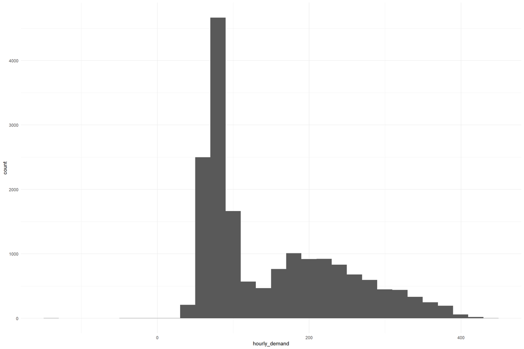

```r
ggplot(sd,aes(hourly_demand))+
  geom_histogram()+
  theme_minimal()
```

> For each of these histograms the x axis is the hourly demand value and the y axis is how many times that value occured. Demand seems to be heavily skewed towards the lower numbers.

## 5.2 Hourly Demand Histogram by Calendar Month

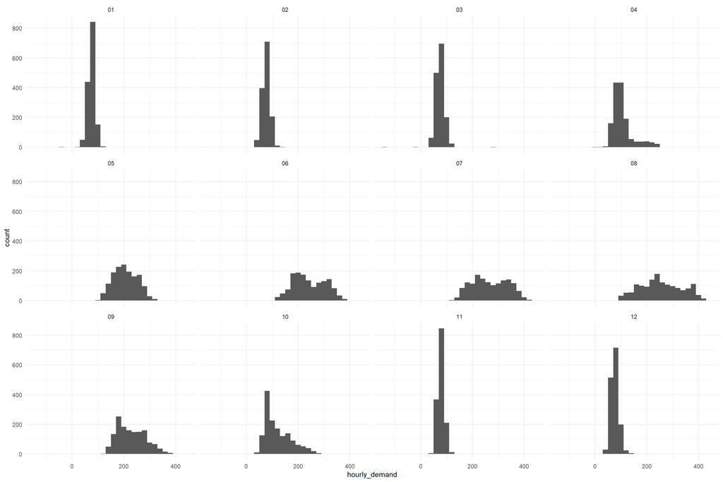

```r
ggplot(sd,aes(hourly_demand))+
  geom_histogram()+
  theme_minimal()+
  facet_wrap(~CalendarMonth)
```

## 5.3 Hourly Demand Histogram by Season

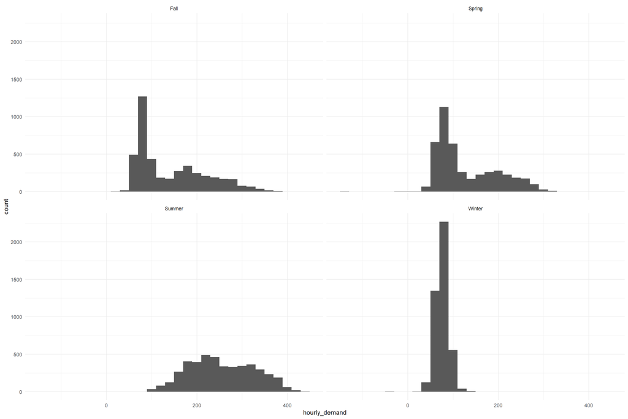

```r
ggplot(sd,aes(hourly_demand))+
  geom_histogram()+
  theme_minimal()+
  facet_wrap(~season)
```

> The ditribution of winter hourly demand values seems to be very different than the other seaons. Seems as though more of the hourly demand values are much lower.

## 5.4 Hourly Demand Histogram by Calendar Year

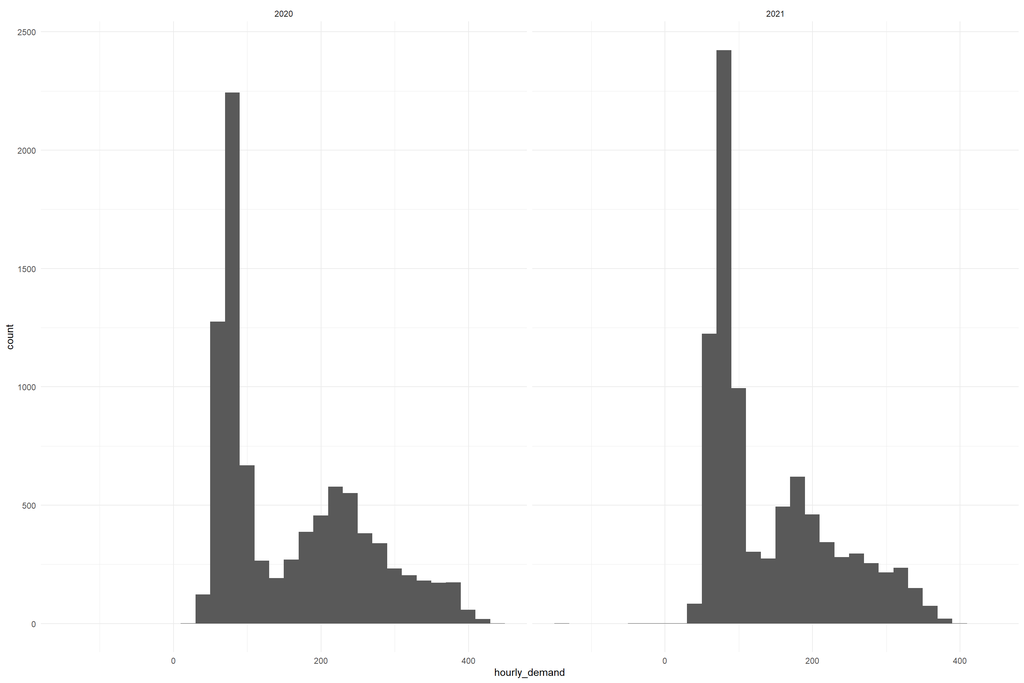

```r
ggplot(sd,aes(hourly_demand))+
  geom_histogram()+
  theme_minimal()+
  facet_wrap(~CalendarYear)
```

> The difference between 2020 and 2021 hourly demands don’t seem very notable.

## 5.5 Average Hourly Demand

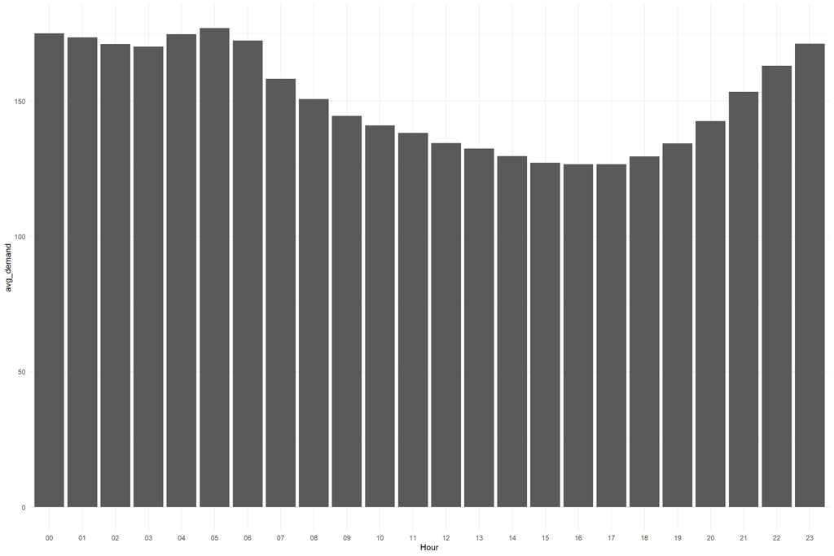

```r
sd%>%
  group_by(Hour)%>%
  summarise(mean(hourly_demand))%>%
  rename(avg_demand = 'mean(hourly_demand)')%>%
  ggplot(aes(Hour, avg_demand))+
  geom_col()+
  theme_minimal()
```

> Demand seems to drop towards the middle of the day. This makes logical sense as people typically water during the early morning hours.

## 5.6 Average Hourly Demand by Season

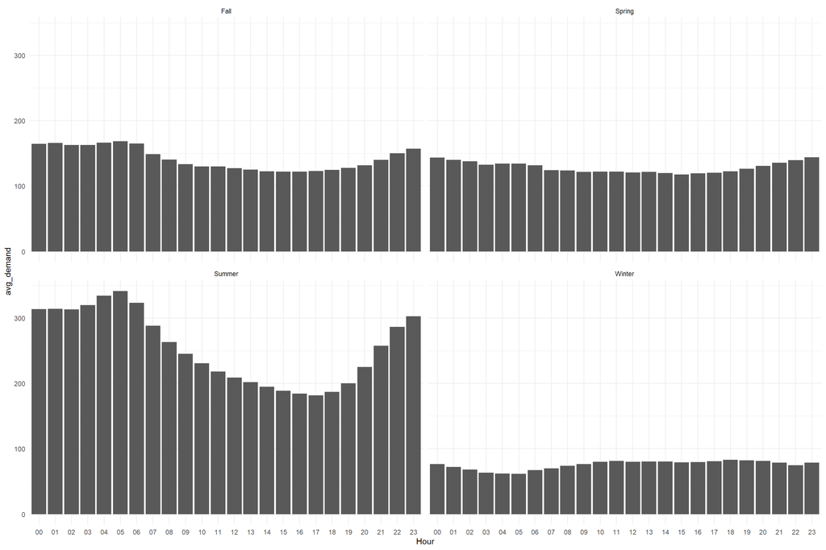

```r
sd%>%
  group_by(season,Hour)%>%
  summarise(mean(hourly_demand))%>%
  rename(avg_demand = 'mean(hourly_demand)')%>%
  ggplot(aes(Hour, avg_demand))+
  geom_col()+
  theme_minimal()+
  facet_wrap(~season)
```

> Seems like the Demand is higher in the Summer as expected and seems to be higher earlier in the day.

## 5.7 Average Season Demand

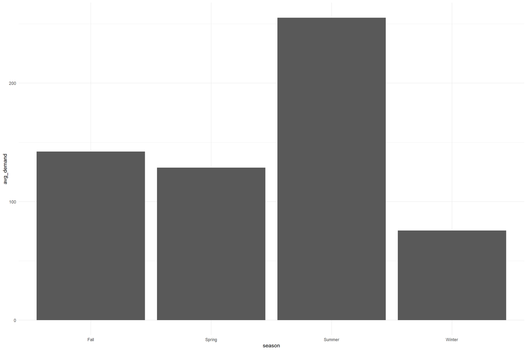

```r
sd%>%
  group_by(season)%>%
  summarise(mean(hourly_demand))%>%
  rename(avg_demand = 'mean(hourly_demand)')%>%
  ggplot(aes(season, avg_demand))+
  geom_col()+
  theme_minimal()
```

> The average demand is much higher in the summer and the next highest is fall.

## 5.8 Average Monthly Demand

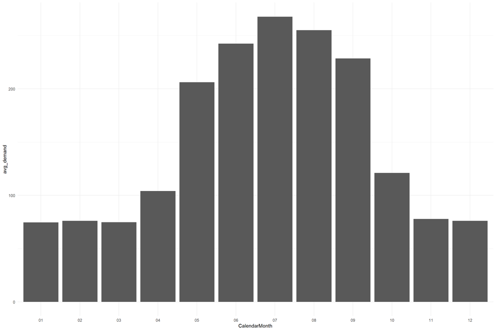

```r
sd%>%
  group_by(CalendarMonth)%>%
  summarise(mean(hourly_demand))%>%
  rename(avg_demand = 'mean(hourly_demand)')%>%
  ggplot(aes(CalendarMonth, avg_demand))+
  geom_col()+
  theme_minimal()
```

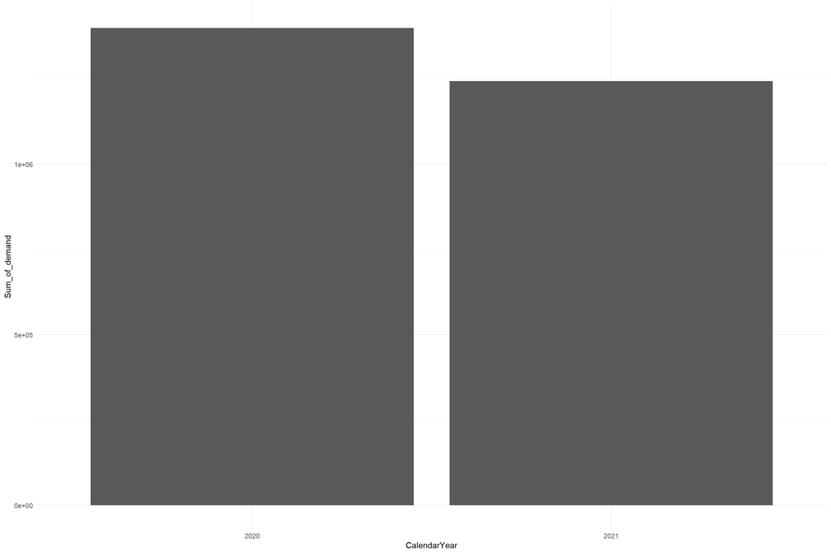

```r
sd%>%
  group_by(CalendarYear)%>%
  summarise(sum(hourly_demand))%>%
  rename(Sum_of_demand = 'sum(hourly_demand)')%>%
  ggplot(aes(CalendarYear, Sum_of_demand))+
  geom_col()+
  theme_minimal()
```

> It looks like 2020 had slightly more water demand as a whole. This makes logical sense because of the drought conditions that were present throughout 2021.

# 6 System Demand By Point Type

```r
kable(head(sp))
```

| well_flow_cfs | purchased_flow_cfs | transported_flow_cfs | treated_flow_cfs | injected_flow_cfs | reservoir_trend_cfs | datetime | datetime_military | date | time | CalendarMonth | CalendarDay | CalendarYear | season |
| --- | --- | --- | --- | --- | --- | --- | --- | --- | --- | --- | --- | --- | --- |
| 25.85019 | 27.85283 | 0 | 14.43277 | 0 | -2.415682 | 2020-01-01 00:59:00 | 01/01/2020 00:59 | 01/01/2020 | 00:59 | 01 | 01 | 2020 | Winter |
| 25.83032 | 27.66055 | 0 | 11.93856 | 0 | 8.680252 | 2020-01-01 01:59:00 | 01/01/2020 01:59 | 01/01/2020 | 01:59 | 01 | 01 | 2020 | Winter |
| 25.83377 | 27.61746 | 0 | 14.43451 | 0 | 17.230239 | 2020-01-01 02:59:00 | 01/01/2020 02:59 | 01/01/2020 | 02:59 | 01 | 01 | 2020 | Winter |
| 25.77743 | 27.45305 | 0 | 14.41635 | 0 | 13.642178 | 2020-01-01 03:59:00 | 01/01/2020 03:59 | 01/01/2020 | 03:59 | 01 | 01 | 2020 | Winter |
| 25.77611 | 27.53296 | 0 | 12.10938 | 0 | 19.484317 | 2020-01-01 04:59:00 | 01/01/2020 04:59 | 01/01/2020 | 04:59 | 01 | 01 | 2020 | Winter |
| 25.78829 | 23.68297 | 0 | 14.40307 | 0 | 19.217513 | 2020-01-01 05:59:00 | 01/01/2020 05:59 | 01/01/2020 | 05:59 | 01 | 01 | 2020 | Winter |

```r
glimpse(sp)
```

```
## Rows: 17,540
## Columns: 14
## $ well_flow_cfs        <dbl> 25.85019, 25.83032, 25.83377, 25.77743, 25.77611,~
## $ purchased_flow_cfs   <dbl> 27.85283, 27.66055, 27.61746, 27.45305, 27.53296,~
## $ transported_flow_cfs <dbl> 0, 0, 0, 0, 0, 0, 0, 0, 0, 0, 0, 0, 0, 0, 0, 0, 0~
## $ treated_flow_cfs     <dbl> 14.43277, 11.93856, 14.43451, 14.41635, 12.10938,~
## $ injected_flow_cfs    <dbl> 0, 0, 0, 0, 0, 0, 0, 0, 0, 0, 0, 0, 0, 0, 0, 0, 0~
## $ reservoir_trend_cfs  <dbl> -2.415682, 8.680252, 17.230239, 13.642178, 19.484~
## $ datetime             <dttm> 2020-01-01 00:59:00, 2020-01-01 01:59:00, 2020-0~
## $ datetime_military    <chr> "01/01/2020 00:59", "01/01/2020 01:59", "01/01/20~
## $ date                 <chr> "01/01/2020", "01/01/2020", "01/01/2020", "01/01/~
## $ time                 <chr> "00:59", "01:59", "02:59", "03:59", "04:59", "05:~
## $ CalendarMonth        <chr> "01", "01", "01", "01", "01", "01", "01", "01", "~
## $ CalendarDay          <chr> "01", "01", "01", "01", "01", "01", "01", "01", "~
## $ CalendarYear         <chr> "2020", "2020", "2020", "2020", "2020", "2020", "~
## $ season               <chr> "Winter", "Winter", "Winter", "Winter", "Winter",~
```

```r
summary(sp)
```

```
##  well_flow_cfs    purchased_flow_cfs transported_flow_cfs treated_flow_cfs
##  Min.   : 0.000   Min.   : 3.355     Min.   :-60.500      Min.   :  5.631
##  1st Qu.: 2.357   1st Qu.:16.114     1st Qu.:-26.240      1st Qu.: 50.000
##  Median :13.433   Median :41.493     Median :-12.100      Median : 79.629
##  Mean   :16.474   Mean   :38.555     Mean   :-16.941      Mean   :112.715
##  3rd Qu.:22.149   3rd Qu.:56.756     3rd Qu.: -4.906      3rd Qu.:174.491
##  Max.   :58.166   Max.   :93.120     Max.   :  0.000      Max.   :306.657
##  injected_flow_cfs    reservoir_trend_cfs     datetime
##  Min.   :-1.093e-02   Min.   :-197.53078   Min.   :2020-01-01 00:59:00
##  1st Qu.: 0.000e+00   1st Qu.: -16.57732   1st Qu.:2020-07-01 19:44:00
##  Median : 0.000e+00   Median :   0.52765   Median :2020-12-31 12:29:00
##  Mean   :-7.010e-07   Mean   :   0.06306   Mean   :2020-12-31 12:27:00
##  3rd Qu.: 0.000e+00   3rd Qu.:  18.25491   3rd Qu.:2021-07-02 07:14:00
##  Max.   : 0.000e+00   Max.   : 210.21380   Max.   :2021-12-31 23:59:00
##  datetime_military      date               time           CalendarMonth
##  Length:17540       Length:17540       Length:17540       Length:17540
##  Class :character   Class :character   Class :character   Class :character
##  Mode  :character   Mode  :character   Mode  :character   Mode  :character
##
##
##
##  CalendarDay        CalendarYear          season
##  Length:17540       Length:17540       Length:17540
##  Class :character   Class :character   Class :character
##  Mode  :character   Mode  :character   Mode  :character
##
##
##
```

## 6.1 Average Well Flow by Season

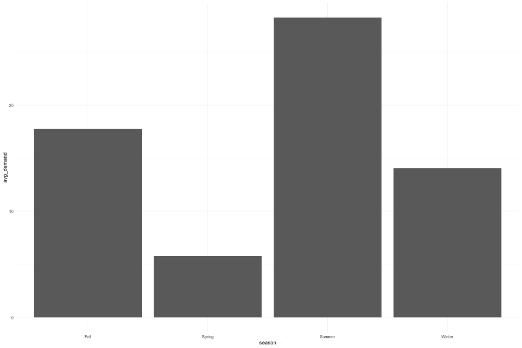

```r
sp%>%
  group_by(season)%>%
  summarise(mean(well_flow_cfs))%>%
  rename(avg_demand = 'mean(well_flow_cfs)')%>%
  ggplot(aes(season, avg_demand))+
  geom_col()+
  theme_minimal()
```

## 6.2 Average Purchased Flow by Season

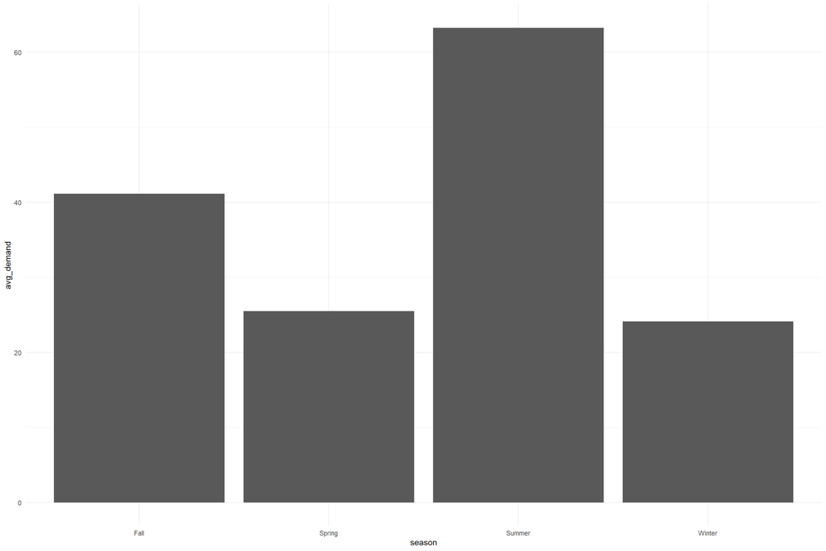

```r
sp%>%
  group_by(season)%>%
  summarise(mean(purchased_flow_cfs))%>%
  rename(avg_demand = 'mean(purchased_flow_cfs)')%>%
  ggplot(aes(season, avg_demand))+
  geom_col()+
  theme_minimal()
```

## 6.3 Average Transported Flow by Season

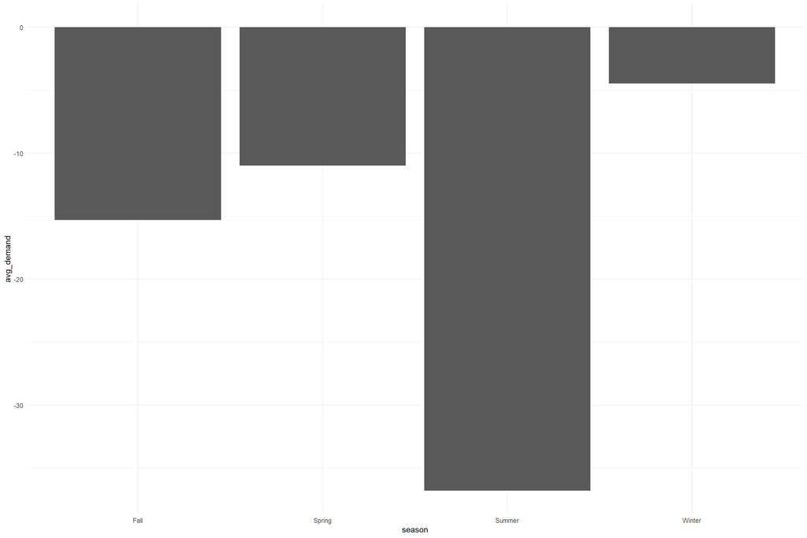

```r
sp%>%
  group_by(season)%>%
  summarise(mean(transported_flow_cfs))%>%
  rename(avg_demand = 'mean(transported_flow_cfs)')%>%
  ggplot(aes(season, avg_demand))+
  geom_col()+
  theme_minimal()
```

## 6.4 Average Treated Flow by Season

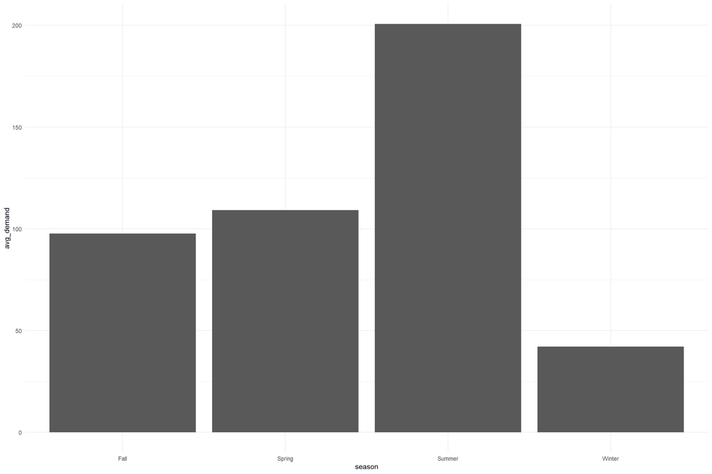

```r
sp%>%
  group_by(season)%>%
  summarise(mean(treated_flow_cfs))%>%
  rename(avg_demand = 'mean(treated_flow_cfs)')%>%
  ggplot(aes(season, avg_demand))+
  geom_col()+
  theme_minimal()
```

## 6.5 Average Injected Flow by Season

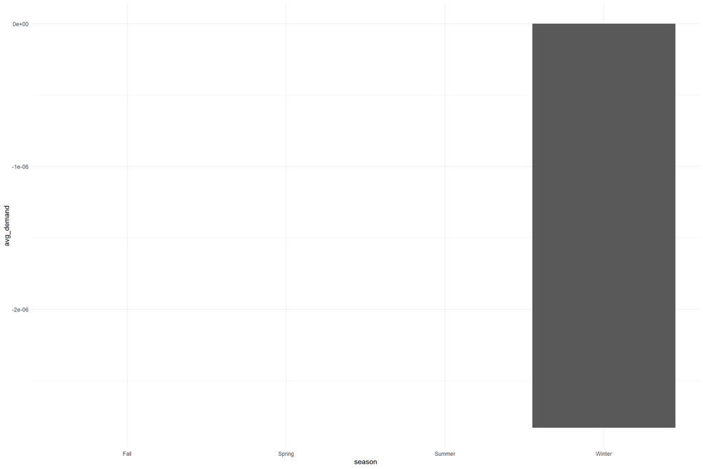

```r
sp%>%
  group_by(season)%>%
  summarise(mean(injected_flow_cfs))%>%
  rename(avg_demand = 'mean(injected_flow_cfs)')%>%
  ggplot(aes(season, avg_demand))+
  geom_col()+
  theme_minimal()
```

> Injected flow seems to only happen during the winter

## 6.6 Injected Flow Histogram

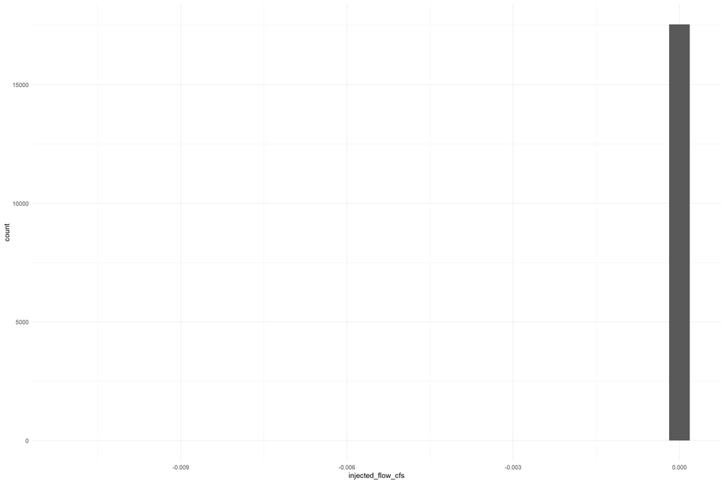

```r
ggplot(sp,aes(injected_flow_cfs))+
  geom_histogram()+
  theme_minimal()
```

> Seems like it’s usually 0.

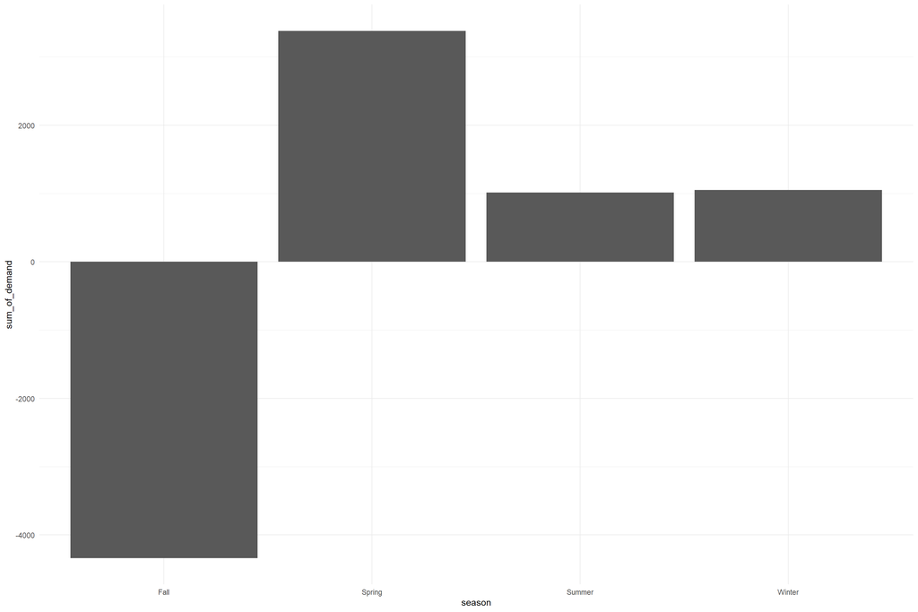

```r
sp%>%
  group_by(season)%>%
  summarise(sum(reservoir_trend_cfs))%>%
  rename(sum_of_demand = 'sum(reservoir_trend_cfs)')%>%
  ggplot(aes(season, sum_of_demand))+
  geom_col()+
  theme_minimal()
```

> I did sum on this one becase it had a lot of weird negative and positive and I wanted to see how it correlated

## 6.8 Reservoir Flow Histogram

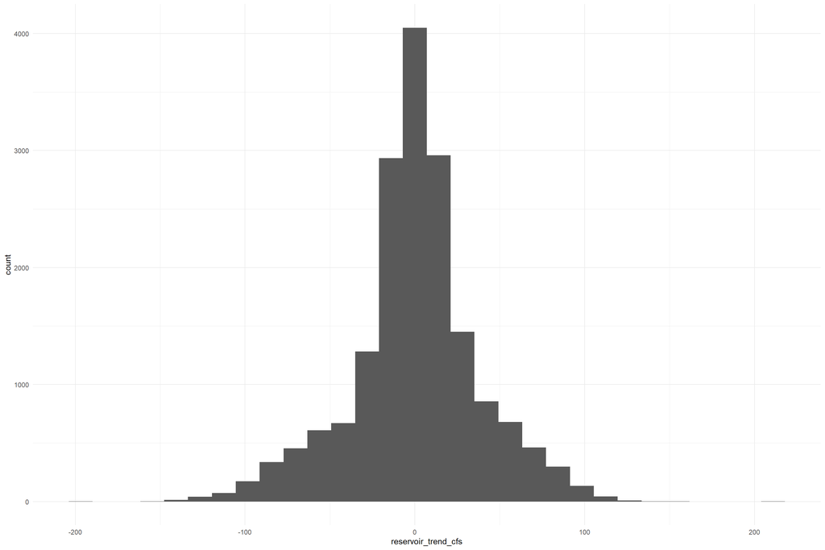

```r
ggplot(sp,aes(reservoir_trend_cfs))+
  geom_histogram()+
  theme_minimal()
```

# 7 Weather Data from Salt Lake Airport

```r
glimpse(wa)
```

```
## Rows: 1,090
## Columns: 13
## $ WeatherDate       <chr> "1/1/2019", "1/2/2019", "1/3/2019", "1/4/2019", "1/5~
## $ CalendarYear      <int> 2019, 2019, 2019, 2019, 2019, 2019, 2019, 2019, 2019~
## $ CalendarMonth     <int> 1, 1, 1, 1, 1, 1, 1, 1, 1, 1, 1, 1, 1, 1, 1, 1, 1, 1~
## $ CalendarDay       <int> 1, 2, 3, 4, 5, 6, 7, 8, 9, 10, 11, 12, 13, 14, 15, 1~
## $ TemperatureMax    <dbl> 23.18, 25.16, 30.20, 30.20, 30.20, 37.04, 39.92, 39.~
## $ TemperatureMin    <dbl> 6.26, 11.12, 13.10, 13.10, 13.10, 28.22, 32.00, 27.1~
## $ TemperatureMean   <dbl> 14.72, 18.14, 21.65, 21.65, 21.65, 32.63, 35.96, 33.~
## $ Precipitation     <dbl> 0.00, 0.00, 0.00, 0.00, 0.00, 0.22, 0.07, 0.00, 0.00~
## $ CoolingDegreeDays <dbl> 0, 0, 0, 0, 0, 0, 0, 0, 0, 0, 0, 0, 0, 0, 0, 0, 0, 0~
## $ SnowDepth         <dbl> 1.96, 1.96, 1.96, 1.96, 1.96, 1.96, 1.96, 1.96, 1.18~
## $ SnowFall          <dbl> 0.00, 0.00, 0.00, 0.00, 0.00, 0.98, 0.39, 0.00, 0.00~
## $ RainDays          <int> 0, 0, 0, 0, 0, 1, 1, 0, 0, 0, 0, 0, 0, 0, 1, 1, 1, 1~
## $ season            <chr> "Winter", "Winter", "Winter", "Winter", "Winter", "W~
```

```r
summary(wa)
```

```
##  WeatherDate         CalendarYear  CalendarMonth     CalendarDay
##  Length:1090        Min.   :2019   Min.   : 1.000   Min.   : 1.00
##  Class :character   1st Qu.:2019   1st Qu.: 4.000   1st Qu.: 8.00
##  Mode  :character   Median :2020   Median : 7.000   Median :16.00
##                     Mean   :2020   Mean   : 6.506   Mean   :15.71
##                     3rd Qu.:2021   3rd Qu.: 9.000   3rd Qu.:23.00
##                     Max.   :2021   Max.   :12.000   Max.   :31.00
##  TemperatureMax   TemperatureMin  TemperatureMean Precipitation
##  Min.   : 23.18   Min.   : 6.26   Min.   :14.72   Min.   :0.00000
##  1st Qu.: 46.94   1st Qu.:30.20   1st Qu.:39.02   1st Qu.:0.00000
##  Median : 63.50   Median :42.08   Median :52.97   Median :0.00000
##  Mean   : 65.68   Mean   :44.67   Mean   :55.18   Mean   :0.03902
##  3rd Qu.: 86.00   3rd Qu.:59.00   3rd Qu.:72.50   3rd Qu.:0.00000
##  Max.   :107.06   Max.   :82.04   Max.   :93.02   Max.   :0.90000
##  CoolingDegreeDays   SnowDepth         SnowFall          RainDays
##  Min.   : 0.000    Min.   :0.0000   Min.   : 0.0000   Min.   :0.0000
##  1st Qu.: 0.000    1st Qu.:0.0000   1st Qu.: 0.0000   1st Qu.:0.0000
##  Median : 0.000    Median :0.0000   Median : 0.0000   Median :0.0000
##  Mean   : 4.327    Mean   :0.2108   Mean   : 0.1105   Mean   :0.2349
##  3rd Qu.: 7.500    3rd Qu.:0.0000   3rd Qu.: 0.0000   3rd Qu.:0.0000
##  Max.   :28.020    Max.   :7.8700   Max.   :11.6900   Max.   :1.0000
##     season
##  Length:1090
##  Class :character
##  Mode  :character
##
##
##
```

## 7.1 Linear Regression to look at useful predictors

```r
#Clear out redundant columns
merginated=merginated[,c(1,2,8,9,12,13,14)]
mermod<-lm(avgdaily_demand~.,data = merginated)
summary(mermod)
```

```
##
## Call:
## lm(formula = avgdaily_demand ~ ., data = merginated)
##
## Residuals:
##      Min       1Q   Median       3Q      Max
## -109.705  -21.361    1.291   20.156  105.962
##
## Coefficients:
##                   Estimate Std. Error t value Pr(>|t|)
## (Intercept)     651.326164 115.512045   5.639 2.47e-08 ***
## ActualDate       -0.038613   0.006154  -6.274 6.07e-10 ***
## TemperatureMean   3.842844   0.125073  30.725  < 2e-16 ***
## Precipitation   -26.139362  15.432778  -1.694 0.090746 .
## SnowFall          4.234368   2.002773   2.114 0.034838 *
## RainDays         -1.392541   3.877284  -0.359 0.719586
## seasonSpring    -12.611610   3.632204  -3.472 0.000547 ***
## seasonSummer     18.969527   4.555853   4.164 3.51e-05 ***
## seasonWinter     10.215741   4.494115   2.273 0.023313 *
## ---
## Signif. codes:  0 '***' 0.001 '**' 0.01 '*' 0.05 '.' 0.1 ' ' 1
##
## Residual standard error: 32.86 on 717 degrees of freedom
## Multiple R-squared:  0.8459, Adjusted R-squared:  0.8442
## F-statistic: 492.1 on 8 and 717 DF,  p-value: < 2.2e-16
```

> Here we can see that Precipitation has a p value of 0.09. logically rain coming same day should not affect as much as recent days (within a week or so).

## 7.2 Precipitation by Week Number

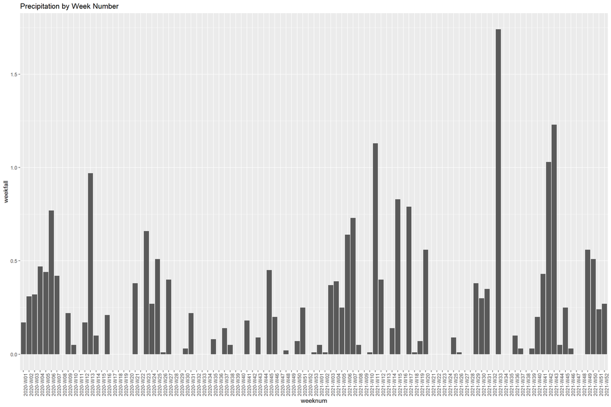

```r
#Create ISO week number identifier column
merginated = merginated %>%
  mutate(weeknum = ISOweek(ActualDate))
#Create list to show precipitation for a given ISO week number
weekref = merginated %>%
  group_by(weeknum) %>%
  summarize(weekfall = sum(Precipitation))
#Visualize
weekref %>%
  ggplot(aes(weeknum,weekfall))+
  geom_col()+
  theme(axis.text.x = element_text(angle = 90))+
  ggtitle("Precipitation by Week Number")
```

```r
#Seems a bit sporadic
```

## 7.3 Linear Regression for impact of prevweekfall

prevweekfall is a variable that represents last weeks rainfall.

```r
#shift column so that list shows prior week precipitation
weekref = shift.column(weekref,columns = "weekfall",len = 1L,up=TRUE)
weekref = weekref[,c(1,3)]
weekref = weekref %>%
  rename(prevweekfall = weekfall.Shifted)
#Merge list to create column showing rainfall by previous week
Merged_Data_Prevweek = merge(merginated,weekref,by.x = "weeknum",by.y = "weeknum",all.y = TRUE,all.x = TRUE)
mergiweek=Merged_Data_Prevweek[,c(2,3,4,6,7,8,9)]
merwod<-lm(avgdaily_demand~.,data = mergiweek)
#Simple regression showing variables with previous week rainfall included
summary(merwod)
```

```
##
## Call:
## lm(formula = avgdaily_demand ~ ., data = mergiweek)
##
## Residuals:
##      Min       1Q   Median       3Q      Max
## -109.142  -19.779    1.583   19.377  103.170
##
## Coefficients:
##                   Estimate Std. Error t value Pr(>|t|)
## (Intercept)     640.752862 115.689934   5.539 4.29e-08 ***
## ActualDate       -0.037972   0.006168  -6.157 1.24e-09 ***
## TemperatureMean   3.869807   0.122931  31.479  < 2e-16 ***
## SnowFall          2.970634   1.939332   1.532  0.12602
## RainDays         -3.952860   3.223787  -1.226  0.22055
## seasonSpring    -11.202566   3.600983  -3.111  0.00194 **
## seasonSummer     18.140895   4.470749   4.058 5.50e-05 ***
## seasonWinter     12.430130   4.455371   2.790  0.00541 **
## prevweekfall    -18.169791   3.928244  -4.625 4.44e-06 ***
## ---
## Signif. codes:  0 '***' 0.001 '**' 0.01 '*' 0.05 '.' 0.1 ' ' 1
##
## Residual standard error: 32.33 on 713 degrees of freedom
##   (4 observations deleted due to missingness)
## Multiple R-squared:  0.8512, Adjusted R-squared:  0.8495
## F-statistic: 509.7 on 8 and 713 DF,  p-value: < 2.2e-16
```

```r
#Does seem to be significant

#Remove temp data frames
remove(mergiweek,weekref,merwod,mermod,mersd,merweth,mershrink,merginated)
```

## 7.4 Average Demand by TemperatureMean

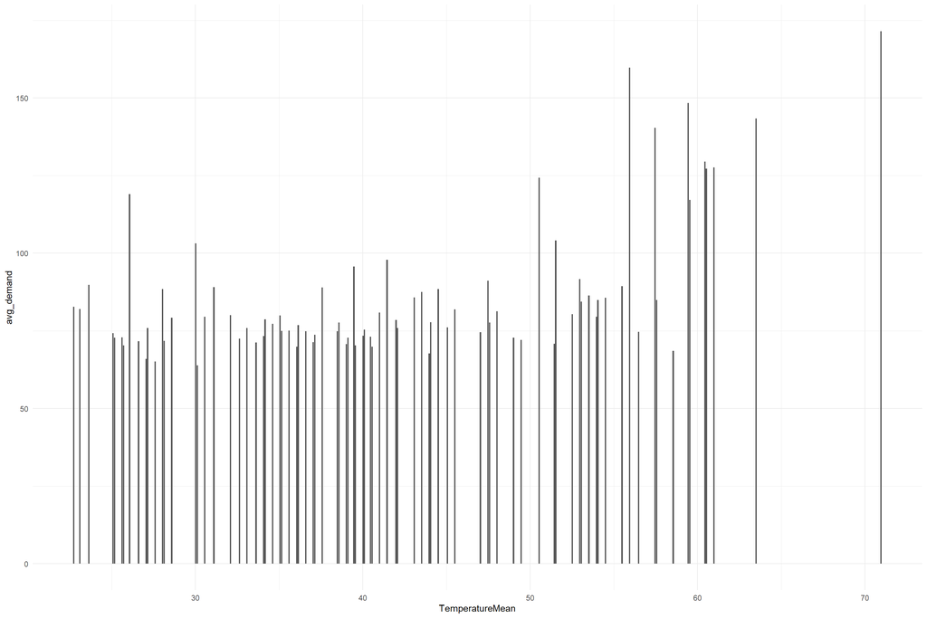

```r
wd%>%
  group_by(TemperatureMean)%>%
  summarise(mean(daily_demand))%>%
  rename(avg_demand = 'mean(daily_demand)')%>%
  ggplot(aes(TemperatureMean, avg_demand))+
  geom_col()+
  theme_minimal()
```

## 7.5 Average Demand by Depth of Snow

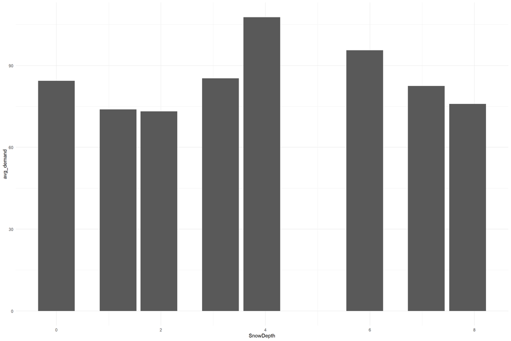

```r
wd%>%
  group_by(SnowDepth)%>%
  summarise(mean(daily_demand))%>%
  rename(avg_demand = 'mean(daily_demand)')%>%
  ggplot(aes(SnowDepth, avg_demand))+
  geom_col()+
  theme_minimal()
```

## 7.6 Average Demand on rainy days vs non rainy

```r
wd%>%
  group_by(RainDays)%>%
  mutate(count_of_days = 1)%>%
  summarise(count_of_days = sum(count_of_days),
            mean(daily_demand))%>%
  rename(avg_demand = 'mean(daily_demand)')%>%
  kable()
```

| RainDays | count_of_days | avg_demand |
| --- | --- | --- |
| 0 | 2352 | 85.35041 |
| 1 | 720 | 79.34993 |

## 7.7 Average Demand on Snow days vs non Snow days

```r
wd%>%
  mutate(snow_day = ifelse(SnowFall>0,1,0))%>%
  group_by(snow_day)%>%
  mutate(count_of_days = 1)%>%
  summarise(count_of_days = sum(count_of_days),
            mean(daily_demand))%>%
  rename(avg_demand = 'mean(daily_demand)')%>%
  kable()
```

| snow_day | count_of_days | avg_demand |
| --- | --- | --- |
| 0 | 2712 | 85.17513 |
| 1 | 360 | 74.66987 |

# 8 Numeric Variable Examination

## 8.1 Correlation to Daily Demand

```r
wdn <- wd%>%
  select_if(is.numeric)

#an attempt to manually look at the most important numberic vars
cwdn <- cor(wdn, use="pairwise.complete.obs")
cwdn1 <- data.frame(sort(cwdn[,'daily_demand'], decreasing = TRUE))

cwdn1%>%
  rename(Correlation = "sort.cwdn....daily_demand....decreasing...TRUE.")%>%
  kable()
```

|  | Correlation |
| --- | --- |
| daily_demand | 1.0000000 |
| TemperatureMean | 0.5495006 |
| TemperatureMin | 0.5364903 |
| TemperatureMax | 0.5355870 |
| CoolingDegreeDays | 0.3853276 |
| SnowDepth | 0.0137351 |
| Precipitation | -0.0349699 |
| SnowFall | -0.1267974 |

## 8.2 Correlation Plot

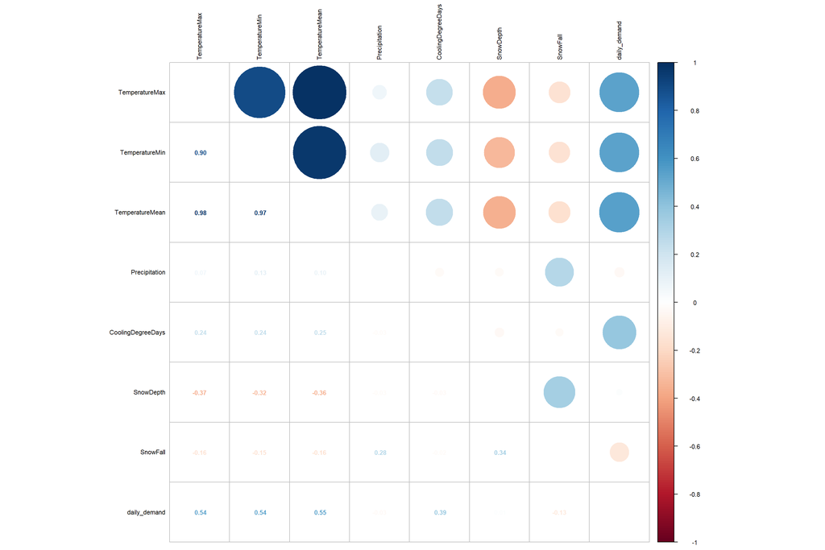

```r
#Calculate correlation
dfcor <- cor(wdn[,unlist(lapply(df, is.numeric))])

#Plot the correlation

#Only Select Numeric Variables
df_numericVars <- which(sapply(wdn, is.numeric))


#correlations of all numeric variables
df_numVar <- wdn[, df_numericVars]
df_cor_numVar <- cor(df_numVar, use="pairwise.complete.obs")

# Correlation of numeric variables with their numbers and shap/color relation to sale price
corrplot.mixed(df_cor_numVar, tl.col="black", tl.pos = "lt", tl.cex = 0.7,cl.cex = .7, number.cex=.7)
```

## 8.3 Correlation Plot 2

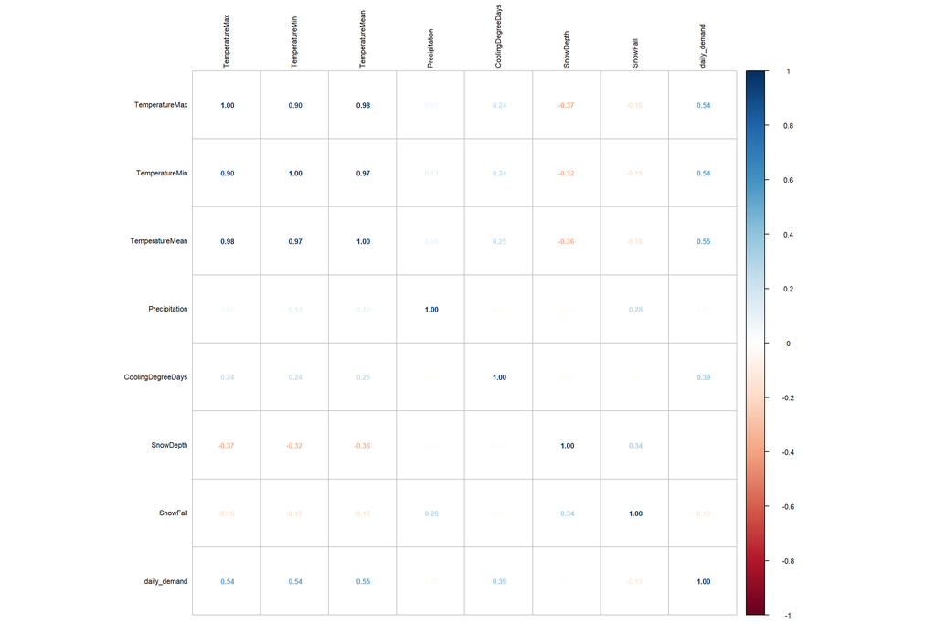

```r
corrplot(df_cor_numVar, tl.col="black", tl.pos = "lt", tl.cex = 0.7,cl.cex = .7, number.cex=.7, method = "number")
```

## 8.4 Correlation of logged mean temprature with logged daily demand

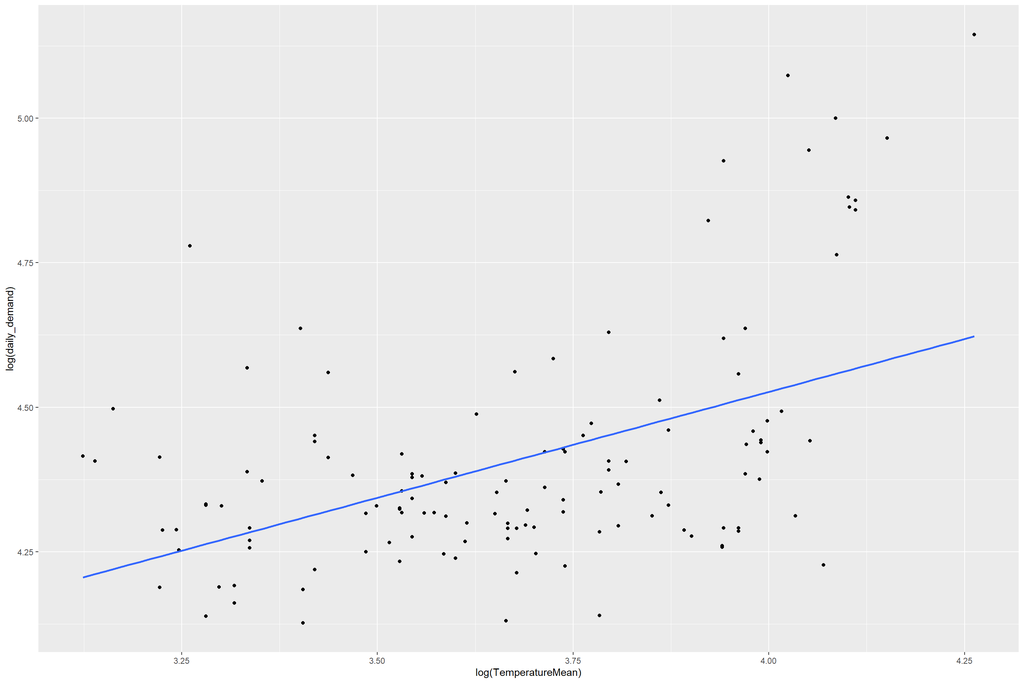

```r
ggplot(wdn, aes(log(TemperatureMean),log(daily_demand)))+
  geom_point()+ stat_smooth(method="lm", se=FALSE)
```

## 8.5 Correlation of logged Precipitation with logged daily demand

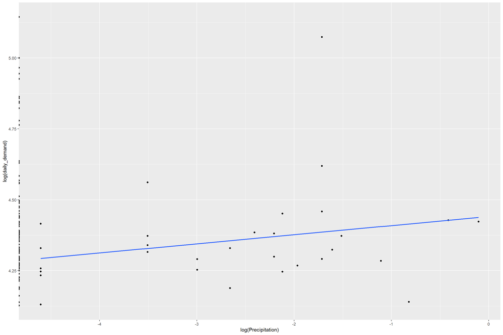

```r
ggplot(wdn, aes(log(Precipitation),log(daily_demand)))+
  geom_point()+ stat_smooth(method="lm", se=FALSE)
```

## 8.6 Correlation of logged SnowFall with logged daily demand

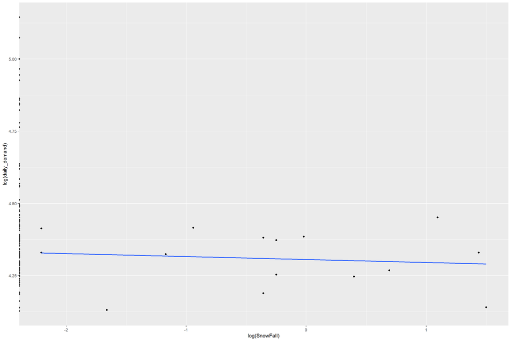

```r
ggplot(wdn, aes(log(SnowFall),log(daily_demand)))+
  geom_point()+ stat_smooth(method="lm", se=FALSE)
```